# MRI made easy (…well almost)

Hans H. Schild (Dept of Radiology, Univ of Bonn Medical Center)

Korean translation by Do-Joon Yi (Dept of Psychology, Yonsei Univ)

2022-03-27

# 이 책에 관하여

이 책은 자기공명영상(magnetic resonance imaging; MRI)을 소개한다. 물리학을 공부한 적이 없어도 MRI에 관해 알고 싶어하는 이들을 위해 쓰여졌다. 여러분이 여기에 속한다면 이 책을 처음부터 끝까지 읽기 바란다. 앉은 자리에서 한 번에 읽을 필요는 없다. 주제가 무척 복잡하지만 결코 이해할 수 없을 정도는 아니다. 그러나 집중하고 숙고해야 한다. 나는 여러분이 가끔 책을 내려놓고 휴식을 취하길 제안한다. 그래야 책을 끝까지 볼 수 있을 것이다. 휴식 후에는 꼭 다시 돌아와야 한다.

This website is a tribute to Dr. H. H. Schild for his book, “MRI made easy (…well almost).”  
본 웹페이지는 1990년에 Schering AG(Berlin/Bergkamen)에 의해 출간되었고 현재 웹에서 [PDF 파일](https://rads.web.unc.edu/wp-content/uploads/sites/12234/2018/05/Phy-MRI-Made-Easy.pdf)로 공유되는 판본을 번역한 내용입니다. 1990년 이후 개정판이 하드카피로 출간되었는지는 알 수 없으나 최근 앱으로 개발되어 [애플스토어](https://apps.apple.com/us/app/mri-made-easy-well-almost/id1077847614)를 통해 무료로 공개되고 있습니다.  
저자인 Hans H. Schild 박사님에 관한 정보는 이 책에 나오지 않고 현재 재직중인 대학병원 홈페이지에서도 찾기가 어렵습니다. 그러나 아직 아직 활발히 연구하고 계시고, 이메일에도 금새 답장을 보내주십니다. Schild 박사님의 연구논문은 [Google Scholar](https://scholar.google.co.kr/citations?user=KP9OXQEAAAAJ&hl=en&oi=sra)에서 검색해볼 수 있습니다.  
이 책은 MRI의 기본 원리를 그 어떤 자료보다 쉽고 재미있게 설명합니다. 이를 자연스러운 우리말 문장으로 옮기려고 노력하였으나 어색하고 문법에 맞지 않는 표현이 어딘가 있을 겁니다. 그런 경우에는 PDF나 앱을 참고바랍니다. 바로잡아야 하는 내용은 dojoon.yi@yonsei.ac.kr로 보내주십시오.  
앱에서는 전자기장의 변화를 동영상으로 제시하고 있습니다. 본 번역문의 그림과 비교해보면 재미있을 겁니다. 본문의 내용은 크게 다르지 않습니다.  
이 책의 판권은 Bayer가 보유하고 있습니다. 허락이 없이 본문의 내용이나 그림을 사용할 수 없습니다.

이해하기 어려운 주제들은 한 번 이상 반복하여 다루었으므로 독자는 책을 끝낼 때까지 주제를 충분히 이해하고 기억할 수 있을 것이다.

이 책을 쓰면서 몇 가지 중요한 개론서의 도움을 받았다. 그 목록은 참고문헌에 있으므로, 분량 상 다루지 못한 정보가 필요할 때 참고하기 바란다. 사실 이 책의 목적은 자기공명영상 전체를 설명하는 것이 아니다. 더 많은 독서를 위한 에피타이저로서의 역할이 이 책의 목적이다.

# 제1장

1. 시작(Let us start…)
2. 양성자의 세차운동(The movement of protons - precession)
3. 좌표체계(Introducing the coordinate system)
4. 전파 주입(Sending in a radio wave)
5. 전파의 채찍질(The whip-like effects of a radio wave)
6. 자화와 종단 완화(Magnetization and longitudinal relaxation)

# 제2장

7. 자화와 횡단 완화(Magnetization and transversal relaxation)
8. T1과 T2 완화에 관한 추가사항(More about T1 and T2 relaxation)

# 제3장

9. 자화 합산(Magnetization and their sum)
10. 반복, TR, 대비(About repetition, TR and contrast)
11. T2-가중, 토끼, 스핀 에코(T2-weighting, rabbits and a spin echo)
12. T2-가중 영상 살펴보기(T2-weighting images - a closer look)

# 제4장

13. 스핀 에코 시퀀스(The spin echo sequence…)
14. TR과 TE, 영상 대비(How TR and TE influence image contrast)
15. 영상 종류 구별하기(Practical hints to image interpretation)
16. 흐름과 함께 사라지다(Gone with the flow)
17. MR 조영제(What about MR contrast media?)

# 제5장

18. 부분 포화 및 포화 회복(Partial saturation and saturation recovery)
19. 반전 회복 시퀀스(The inversion recovery sequence)
20. 고속 이미징(Fast and faster imaging)
21. 촬영 시간(Imaging time)
22. MR 신호 강도(Signal intensity in MR)
23. 절편 선택(How can we select a slice to examine?)
24. 핵(Nuclei)
25. 하드웨어(Magnets, coils and other things)

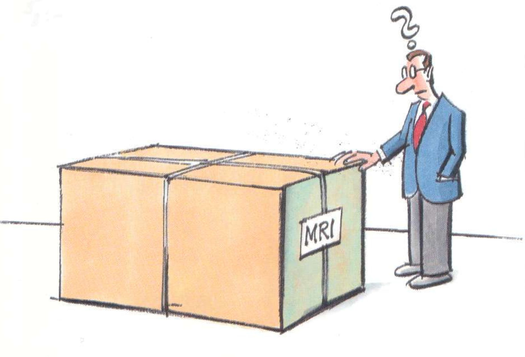

[다음 장(1장)으로]